# Optimal Treatment Analysis

## Outcome Variable

**Outcome Variable:** whz

## Predictor Variables

**Intervention Variable:** nrooms

**Adjustment Set:**

- arm
- sex
- W_mage
- meducyrs
- feducyrs
- hhwealth_quart
- hfoodsec
- W_mhtcm
- W_nchldlt5
- W_parity
- impfloor
- impsan
- safeh20
- delta_W_mage
- delta_meducyrs
- delta_feducyrs
- delta_hhwealth_quart
- delta_hfoodsec
- delta_W_mhtcm
- delta_W_nchldlt5
- delta_W_parity
- delta_impfloor
- delta_impsan
- delta_safeh20

## Stratifying Variables

The analysis was stratified on these variable(s):

- agecat
- studyid
- country

## Data Summary

| agecat | studyid | country | nrooms | n_cell | n |
| --- | --- | --- | --- | --- | --- |
| Birth | ki0047075b-MAL-ED | BANGLADESH | 4+ | 12 | 222 |
| Birth | ki0047075b-MAL-ED | BANGLADESH | 1 | 135 | 222 |
| Birth | ki0047075b-MAL-ED | BANGLADESH | 2 | 47 | 222 |
| Birth | ki0047075b-MAL-ED | BANGLADESH | 3 | 28 | 222 |
| Birth | ki0047075b-MAL-ED | BRAZIL | 4+ | 99 | 167 |
| Birth | ki0047075b-MAL-ED | BRAZIL | 1 | 3 | 167 |
| Birth | ki0047075b-MAL-ED | BRAZIL | 2 | 19 | 167 |
| Birth | ki0047075b-MAL-ED | BRAZIL | 3 | 46 | 167 |
| Birth | ki0047075b-MAL-ED | INDIA | 4+ | 22 | 188 |
| Birth | ki0047075b-MAL-ED | INDIA | 1 | 68 | 188 |
| Birth | ki0047075b-MAL-ED | INDIA | 2 | 66 | 188 |
| Birth | ki0047075b-MAL-ED | INDIA | 3 | 32 | 188 |
| Birth | ki0047075b-MAL-ED | NEPAL | 4+ | 94 | 166 |
| Birth | ki0047075b-MAL-ED | NEPAL | 1 | 34 | 166 |
| Birth | ki0047075b-MAL-ED | NEPAL | 2 | 21 | 166 |
| Birth | ki0047075b-MAL-ED | NEPAL | 3 | 17 | 166 |
| Birth | ki0047075b-MAL-ED | PERU | 4+ | 127 | 252 |
| Birth | ki0047075b-MAL-ED | PERU | 1 | 17 | 252 |
| Birth | ki0047075b-MAL-ED | PERU | 2 | 51 | 252 |
| Birth | ki0047075b-MAL-ED | PERU | 3 | 57 | 252 |
| Birth | ki0047075b-MAL-ED | SOUTH AFRICA | 4+ | 159 | 216 |
| Birth | ki0047075b-MAL-ED | SOUTH AFRICA | 1 | 14 | 216 |
| Birth | ki0047075b-MAL-ED | SOUTH AFRICA | 2 | 20 | 216 |
| Birth | ki0047075b-MAL-ED | SOUTH AFRICA | 3 | 23 | 216 |
| Birth | ki0047075b-MAL-ED | TANZANIA, UNITED REPUBLIC OF | 4+ | 54 | 114 |
| Birth | ki0047075b-MAL-ED | TANZANIA, UNITED REPUBLIC OF | 1 | 6 | 114 |
| Birth | ki0047075b-MAL-ED | TANZANIA, UNITED REPUBLIC OF | 2 | 23 | 114 |
| Birth | ki0047075b-MAL-ED | TANZANIA, UNITED REPUBLIC OF | 3 | 31 | 114 |
| Birth | ki1000108-CMC-V-BCS-2002 | INDIA | 4+ | 5 | 88 |
| Birth | ki1000108-CMC-V-BCS-2002 | INDIA | 1 | 39 | 88 |

[output cut: 154 more lines]

The following strata were considered:

- agecat: 24 months, studyid: ki0047075b-MAL-ED, country: BANGLADESH
- agecat: 24 months, studyid: ki0047075b-MAL-ED, country: BRAZIL
- agecat: 24 months, studyid: ki0047075b-MAL-ED, country: INDIA
- agecat: 24 months, studyid: ki0047075b-MAL-ED, country: NEPAL
- agecat: 24 months, studyid: ki0047075b-MAL-ED, country: PERU
- agecat: 24 months, studyid: ki0047075b-MAL-ED, country: SOUTH AFRICA
- agecat: 24 months, studyid: ki0047075b-MAL-ED, country: TANZANIA, UNITED REPUBLIC OF
- agecat: 24 months, studyid: ki1000108-CMC-V-BCS-2002, country: INDIA
- agecat: 24 months, studyid: ki1000108-IRC, country: INDIA
- agecat: 24 months, studyid: ki1017093b-PROVIDE, country: BANGLADESH
- agecat: 24 months, studyid: ki1017093c-NIH-Crypto, country: BANGLADESH
- agecat: 24 months, studyid: ki1113344-GMS-Nepal, country: NEPAL
- agecat: 24 months, studyid: ki1114097-CONTENT, country: PERU
- agecat: 24 months, studyid: ki1135781-COHORTS, country: INDIA
- agecat: 24 months, studyid: kiGH5241-JiVitA-3, country: BANGLADESH
- agecat: 24 months, studyid: kiGH5241-JiVitA-4, country: BANGLADESH
- agecat: 6 months, studyid: ki0047075b-MAL-ED, country: BANGLADESH
- agecat: 6 months, studyid: ki0047075b-MAL-ED, country: BRAZIL
- agecat: 6 months, studyid: ki0047075b-MAL-ED, country: INDIA
- agecat: 6 months, studyid: ki0047075b-MAL-ED, country: NEPAL
- agecat: 6 months, studyid: ki0047075b-MAL-ED, country: PERU
- agecat: 6 months, studyid: ki0047075b-MAL-ED, country: SOUTH AFRICA
- agecat: 6 months, studyid: ki0047075b-MAL-ED, country: TANZANIA, UNITED REPUBLIC OF
- agecat: 6 months, studyid: ki1000108-CMC-V-BCS-2002, country: INDIA
- agecat: 6 months, studyid: ki1000108-IRC, country: INDIA
- agecat: 6 months, studyid: ki1017093b-PROVIDE, country: BANGLADESH
- agecat: 6 months, studyid: ki1017093c-NIH-Crypto, country: BANGLADESH
- agecat: 6 months, studyid: ki1113344-GMS-Nepal, country: NEPAL
- agecat: 6 months, studyid: ki1114097-CONTENT, country: PERU
- agecat: 6 months, studyid: ki1135781-COHORTS, country: INDIA
- agecat: 6 months, studyid: kiGH5241-JiVitA-3, country: BANGLADESH
- agecat: 6 months, studyid: kiGH5241-JiVitA-4, country: BANGLADESH
- agecat: Birth, studyid: ki0047075b-MAL-ED, country: BANGLADESH
- agecat: Birth, studyid: ki0047075b-MAL-ED, country: BRAZIL
- agecat: Birth, studyid: ki0047075b-MAL-ED, country: INDIA
- agecat: Birth, studyid: ki0047075b-MAL-ED, country: NEPAL
- agecat: Birth, studyid: ki0047075b-MAL-ED, country: PERU
- agecat: Birth, studyid: ki0047075b-MAL-ED, country: SOUTH AFRICA
- agecat: Birth, studyid: ki0047075b-MAL-ED, country: TANZANIA, UNITED REPUBLIC OF
- agecat: Birth, studyid: ki1000108-CMC-V-BCS-2002, country: INDIA
- agecat: Birth, studyid: ki1000108-IRC, country: INDIA
- agecat: Birth, studyid: ki1017093c-NIH-Crypto, country: BANGLADESH
- agecat: Birth, studyid: ki1114097-CONTENT, country: PERU
- agecat: Birth, studyid: ki1135781-COHORTS, country: INDIA
- agecat: Birth, studyid: kiGH5241-JiVitA-3, country: BANGLADESH
- agecat: Birth, studyid: kiGH5241-JiVitA-4, country: BANGLADESH

### Dropped Strata

Some strata were dropped due to rare outcomes:

- agecat: Birth, studyid: ki0047075b-MAL-ED, country: BRAZIL
- agecat: Birth, studyid: ki1017093c-NIH-Crypto, country: BANGLADESH
- agecat: Birth, studyid: ki1114097-CONTENT, country: PERU
- agecat: Birth, studyid: kiGH5241-JiVitA-4, country: BANGLADESH
- agecat: 6 months, studyid: ki0047075b-MAL-ED, country: BRAZIL
- agecat: 24 months, studyid: ki0047075b-MAL-ED, country: BRAZIL

## Methods Detail

We’re interested in the causal parameters $E[Y_a]$ for all values of $a \in \mathcal{A}$. These parameters represent the mean outcome if, possibly contrary to fact, we intervened to set all units to have $A=a$. Under the randomization and positivity assumptions, these are identified by the statistical parameters $\psi_a=E_W[E_{Y|A,W}(Y|A=a,W)]$. In addition, we’re interested in the mean of $Y$, $E[Y]$ under no intervention (the observed mean). We will estimate these parameters by using SuperLearner to fit the relevant likelihood factors – $E_{Y|A,W}(Y|A=a,W)$ and $p(A=a|W)$, and then updating our likelihood fit using a joint TMLE.

For unadjusted analyses ($W=\{\}$), initial likelihoods were estimated using Lrnr_glm to estimate the simple $E(Y|A)$ and Lrnr_mean to estimate $p(A)$. For adjusted analyses, a small library containing Lrnr_glmnet, Lrnr_xgboost, and Lrnr_mean was used.

# Results Detail

## Results Plots

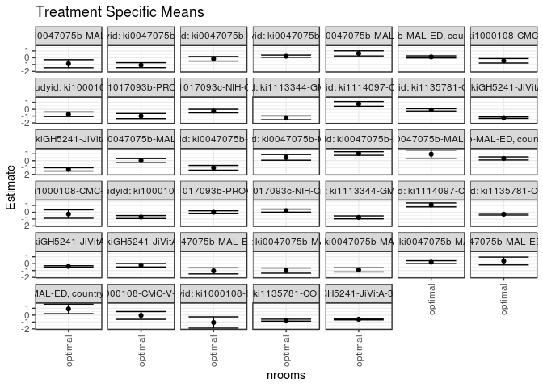

## Results Table

### Parameter: TSM

| agecat | studyid | country | intervention_level | baseline_level | estimate | ci_lower | ci_upper |
| --- | --- | --- | --- | --- | --- | --- | --- |
| Birth | ki0047075b-MAL-ED | BANGLADESH | optimal | observed | -1.0507340 | -1.4900692 | -0.6113987 |
| Birth | ki0047075b-MAL-ED | INDIA | optimal | observed | -1.0135819 | -1.3903704 | -0.6367934 |
| Birth | ki0047075b-MAL-ED | NEPAL | optimal | observed | -0.9071981 | -1.2083363 | -0.6060599 |
| Birth | ki0047075b-MAL-ED | PERU | optimal | observed | 0.2172903 | 0.0094167 | 0.4251639 |
| Birth | ki0047075b-MAL-ED | SOUTH AFRICA | optimal | observed | 0.3834248 | -0.1863431 | 0.9531928 |
| Birth | ki0047075b-MAL-ED | TANZANIA, UNITED REPUBLIC OF | optimal | observed | 0.9052730 | 0.2063291 | 1.6042169 |
| Birth | ki1000108-CMC-V-BCS-2002 | INDIA | optimal | observed | -0.0465869 | -0.6113831 | 0.5182092 |
| Birth | ki1000108-IRC | INDIA | optimal | observed | -1.0744264 | -1.8984310 | -0.2504217 |
| Birth | ki1135781-COHORTS | INDIA | optimal | observed | -0.7327081 | -0.8729303 | -0.5924860 |
| Birth | kiGH5241-JiVitA-3 | BANGLADESH | optimal | observed | -0.6008284 | -0.6907768 | -0.5108799 |
| 6 months | ki0047075b-MAL-ED | BANGLADESH | optimal | observed | 0.0349422 | -0.2415603 | 0.3114447 |
| 6 months | ki0047075b-MAL-ED | INDIA | optimal | observed | -1.0303189 | -1.3771601 | -0.6834777 |
| 6 months | ki0047075b-MAL-ED | NEPAL | optimal | observed | 0.4829929 | 0.0696023 | 0.8963836 |
| 6 months | ki0047075b-MAL-ED | PERU | optimal | observed | 1.0477216 | 0.7897648 | 1.3056785 |
| 6 months | ki0047075b-MAL-ED | SOUTH AFRICA | optimal | observed | 0.9529785 | 0.3623454 | 1.5436115 |
| 6 months | ki0047075b-MAL-ED | TANZANIA, UNITED REPUBLIC OF | optimal | observed | 0.3315343 | 0.1026744 | 0.5603943 |
| 6 months | ki1000108-CMC-V-BCS-2002 | INDIA | optimal | observed | -0.2658177 | -0.8828442 | 0.3512088 |
| 6 months | ki1000108-IRC | INDIA | optimal | observed | -0.7039023 | -0.9229076 | -0.4848969 |
| 6 months | ki1017093b-PROVIDE | BANGLADESH | optimal | observed | -0.0034181 | -0.2145078 | 0.2076715 |
| 6 months | ki1017093c-NIH-Crypto | BANGLADESH | optimal | observed | 0.2346697 | 0.0125639 | 0.4567754 |
| 6 months | ki1113344-GMS-Nepal | NEPAL | optimal | observed | -0.7527267 | -0.9683475 | -0.5371060 |
| 6 months | ki1114097-CONTENT | PERU | optimal | observed | 1.0772536 | 0.7886916 | 1.3658155 |
| 6 months | ki1135781-COHORTS | INDIA | optimal | observed | -0.2885605 | -0.4130300 | -0.1640910 |
| 6 months | kiGH5241-JiVitA-3 | BANGLADESH | optimal | observed | -0.4039724 | -0.5044573 | -0.3034876 |
| 6 months | kiGH5241-JiVitA-4 | BANGLADESH | optimal | observed | -0.2331996 | -0.4854443 | 0.0190451 |
| 24 months | ki0047075b-MAL-ED | BANGLADESH | optimal | observed | -0.8762626 | -1.4628617 | -0.2896634 |
| 24 months | ki0047075b-MAL-ED | INDIA | optimal | observed | -1.0894309 | -1.4481360 | -0.7307258 |
| 24 months | ki0047075b-MAL-ED | NEPAL | optimal | observed | -0.1549247 | -0.4886099 | 0.1787606 |
| 24 months | ki0047075b-MAL-ED | PERU | optimal | observed | 0.2226093 | 0.0566931 | 0.3885254 |
| 24 months | ki0047075b-MAL-ED | SOUTH AFRICA | optimal | observed | 0.6399470 | 0.2624107 | 1.0174833 |
| 24 months | ki0047075b-MAL-ED | TANZANIA, UNITED REPUBLIC OF | optimal | observed | 0.1215694 | -0.0344678 | 0.2776066 |
| 24 months | ki1000108-CMC-V-BCS-2002 | INDIA | optimal | observed | -0.4479747 | -0.7775923 | -0.1183571 |
| 24 months | ki1000108-IRC | INDIA | optimal | observed | -0.7309119 | -1.0712031 | -0.3906206 |
| 24 months | ki1017093b-PROVIDE | BANGLADESH | optimal | observed | -0.9915071 | -1.3710615 | -0.6119527 |
| 24 months | ki1017093c-NIH-Crypto | BANGLADESH | optimal | observed | -0.2602001 | -0.5235948 | 0.0031945 |
| 24 months | ki1113344-GMS-Nepal | NEPAL | optimal | observed | -1.2575844 | -1.5358318 | -0.9793370 |
| 24 months | ki1114097-CONTENT | PERU | optimal | observed | 0.7779246 | 0.4393120 | 1.1165372 |
| 24 months | ki1135781-COHORTS | INDIA | optimal | observed | -0.0869124 | -0.2536269 | 0.0798021 |
| 24 months | kiGH5241-JiVitA-3 | BANGLADESH | optimal | observed | -1.2311280 | -1.3393356 | -1.1229203 |
| 24 months | kiGH5241-JiVitA-4 | BANGLADESH | optimal | observed | -1.2629769 | -1.5020976 | -1.0238561 |

### Parameter: E(Y)

| agecat | studyid | country | intervention_level | baseline_level | estimate | ci_lower | ci_upper |
| --- | --- | --- | --- | --- | --- | --- | --- |
| Birth | ki0047075b-MAL-ED | BANGLADESH | observed | observed | -0.9902252 | -1.1311070 | -0.8493435 |
| Birth | ki0047075b-MAL-ED | INDIA | observed | observed | -1.0536702 | -1.1965043 | -0.9108361 |
| Birth | ki0047075b-MAL-ED | NEPAL | observed | observed | -0.9174699 | -1.0573845 | -0.7775553 |
| Birth | ki0047075b-MAL-ED | PERU | observed | observed | -0.0384921 | -0.1542085 | 0.0772244 |
| Birth | ki0047075b-MAL-ED | SOUTH AFRICA | observed | observed | -0.0073148 | -0.1632037 | 0.1485740 |
| Birth | ki0047075b-MAL-ED | TANZANIA, UNITED REPUBLIC OF | observed | observed | 0.8024561 | 0.5990025 | 1.0059098 |
| Birth | ki1000108-CMC-V-BCS-2002 | INDIA | observed | observed | -0.6275000 | -0.9746292 | -0.2803708 |
| Birth | ki1000108-IRC | INDIA | observed | observed | -1.0053372 | -1.1922119 | -0.8184626 |
| Birth | ki1135781-COHORTS | INDIA | observed | observed | -0.9778087 | -1.0126530 | -0.9429644 |
| Birth | kiGH5241-JiVitA-3 | BANGLADESH | observed | observed | -0.7660941 | -0.7930639 | -0.7391243 |
| 6 months | ki0047075b-MAL-ED | BANGLADESH | observed | observed | -0.1354618 | -0.2647919 | -0.0061317 |
| 6 months | ki0047075b-MAL-ED | INDIA | observed | observed | -0.7056667 | -0.8312524 | -0.5800810 |
| 6 months | ki0047075b-MAL-ED | NEPAL | observed | observed | 0.1110452 | -0.0202712 | 0.2423616 |
| 6 months | ki0047075b-MAL-ED | PERU | observed | observed | 1.0527407 | 0.9299728 | 1.1755087 |
| 6 months | ki0047075b-MAL-ED | SOUTH AFRICA | observed | observed | 0.5403280 | 0.3866002 | 0.6940558 |
| 6 months | ki0047075b-MAL-ED | TANZANIA, UNITED REPUBLIC OF | observed | observed | 0.5170513 | 0.3872178 | 0.6468847 |
| 6 months | ki1000108-CMC-V-BCS-2002 | INDIA | observed | observed | -0.5026766 | -0.6536848 | -0.3516685 |
| 6 months | ki1000108-IRC | INDIA | observed | observed | -0.5900821 | -0.7252457 | -0.4549185 |
| 6 months | ki1017093b-PROVIDE | BANGLADESH | observed | observed | -0.2083706 | -0.2927992 | -0.1239419 |
| 6 months | ki1017093c-NIH-Crypto | BANGLADESH | observed | observed | 0.0297622 | -0.0491685 | 0.1086930 |
| 6 months | ki1113344-GMS-Nepal | NEPAL | observed | observed | -0.6047987 | -0.6909649 | -0.5186325 |
| 6 months | ki1114097-CONTENT | PERU | observed | observed | 1.0684318 | 0.9515274 | 1.1853362 |
| 6 months | ki1135781-COHORTS | INDIA | observed | observed | -0.7088012 | -0.7411274 | -0.6764750 |
| 6 months | kiGH5241-JiVitA-3 | BANGLADESH | observed | observed | -0.5891495 | -0.6166582 | -0.5616408 |
| 6 months | kiGH5241-JiVitA-4 | BANGLADESH | observed | observed | -0.3684250 | -0.4392750 | -0.2975751 |
| 24 months | ki0047075b-MAL-ED | BANGLADESH | observed | observed | -0.8208255 | -0.9429246 | -0.6987264 |
| 24 months | ki0047075b-MAL-ED | INDIA | observed | observed | -0.9522907 | -1.0676596 | -0.8369219 |
| 24 months | ki0047075b-MAL-ED | NEPAL | observed | observed | -0.3764474 | -0.4898516 | -0.2630431 |
| 24 months | ki0047075b-MAL-ED | PERU | observed | observed | 0.1199005 | -0.0000331 | 0.2398341 |
| 24 months | ki0047075b-MAL-ED | SOUTH AFRICA | observed | observed | 0.4267017 | 0.3074751 | 0.5459283 |
| 24 months | ki0047075b-MAL-ED | TANZANIA, UNITED REPUBLIC OF | observed | observed | 0.0500935 | -0.0748234 | 0.1750103 |
| 24 months | ki1000108-CMC-V-BCS-2002 | INDIA | observed | observed | -0.5571505 | -0.6585247 | -0.4557763 |
| 24 months | ki1000108-IRC | INDIA | observed | observed | -0.7416790 | -0.8323562 | -0.6510017 |
| 24 months | ki1017093b-PROVIDE | BANGLADESH | observed | observed | -0.8879412 | -0.9708680 | -0.8050144 |
| 24 months | ki1017093c-NIH-Crypto | BANGLADESH | observed | observed | -0.6103502 | -0.7050157 | -0.5156847 |
| 24 months | ki1113344-GMS-Nepal | NEPAL | observed | observed | -1.1315863 | -1.2192240 | -1.0439487 |
| 24 months | ki1114097-CONTENT | PERU | observed | observed | 0.5668293 | 0.4302437 | 0.7034148 |
| 24 months | ki1135781-COHORTS | INDIA | observed | observed | -0.6612799 | -0.6944511 | -0.6281088 |
| 24 months | kiGH5241-JiVitA-3 | BANGLADESH | observed | observed | -1.2909988 | -1.3235693 | -1.2584284 |
| 24 months | kiGH5241-JiVitA-4 | BANGLADESH | observed | observed | -1.2302244 | -1.2892920 | -1.1711567 |

### Parameter: PAR

| agecat | studyid | country | intervention_level | baseline_level | estimate | ci_lower | ci_upper |
| --- | --- | --- | --- | --- | --- | --- | --- |
| Birth | ki0047075b-MAL-ED | BANGLADESH | optimal | observed | 0.0605088 | -0.3751822 | 0.4961997 |
| Birth | ki0047075b-MAL-ED | INDIA | optimal | observed | -0.0400883 | -0.4022646 | 0.3220880 |
| Birth | ki0047075b-MAL-ED | NEPAL | optimal | observed | -0.0102718 | -0.3002420 | 0.2796984 |
| Birth | ki0047075b-MAL-ED | PERU | optimal | observed | -0.2557824 | -0.4498816 | -0.0616831 |
| Birth | ki0047075b-MAL-ED | SOUTH AFRICA | optimal | observed | -0.3907396 | -0.9360990 | 0.1546197 |
| Birth | ki0047075b-MAL-ED | TANZANIA, UNITED REPUBLIC OF | optimal | observed | -0.1028169 | -0.7804418 | 0.5748081 |
| Birth | ki1000108-CMC-V-BCS-2002 | INDIA | optimal | observed | -0.5809131 | -1.1432773 | -0.0185488 |
| Birth | ki1000108-IRC | INDIA | optimal | observed | 0.0690891 | -0.7264784 | 0.8646566 |
| Birth | ki1135781-COHORTS | INDIA | optimal | observed | -0.2451006 | -0.3854475 | -0.1047537 |
| Birth | kiGH5241-JiVitA-3 | BANGLADESH | optimal | observed | -0.1652657 | -0.2536288 | -0.0769027 |
| 6 months | ki0047075b-MAL-ED | BANGLADESH | optimal | observed | -0.1704040 | -0.4204236 | 0.0796157 |
| 6 months | ki0047075b-MAL-ED | INDIA | optimal | observed | 0.3246522 | 0.0032145 | 0.6460900 |
| 6 months | ki0047075b-MAL-ED | NEPAL | optimal | observed | -0.3719477 | -0.7528321 | 0.0089366 |
| 6 months | ki0047075b-MAL-ED | PERU | optimal | observed | 0.0050191 | -0.2350552 | 0.2450934 |
| 6 months | ki0047075b-MAL-ED | SOUTH AFRICA | optimal | observed | -0.4126505 | -0.9776038 | 0.1523028 |
| 6 months | ki0047075b-MAL-ED | TANZANIA, UNITED REPUBLIC OF | optimal | observed | 0.1855170 | -0.0273903 | 0.3984242 |
| 6 months | ki1000108-CMC-V-BCS-2002 | INDIA | optimal | observed | -0.2368589 | -0.8290815 | 0.3553636 |
| 6 months | ki1000108-IRC | INDIA | optimal | observed | 0.1138202 | -0.0774142 | 0.3050546 |
| 6 months | ki1017093b-PROVIDE | BANGLADESH | optimal | observed | -0.2049524 | -0.4010937 | -0.0088112 |
| 6 months | ki1017093c-NIH-Crypto | BANGLADESH | optimal | observed | -0.2049074 | -0.4121132 | 0.0022984 |
| 6 months | ki1113344-GMS-Nepal | NEPAL | optimal | observed | 0.1479280 | -0.0508604 | 0.3467165 |
| 6 months | ki1114097-CONTENT | PERU | optimal | observed | -0.0088218 | -0.2421446 | 0.2245011 |
| 6 months | ki1135781-COHORTS | INDIA | optimal | observed | -0.4202407 | -0.5453506 | -0.2951308 |
| 6 months | kiGH5241-JiVitA-3 | BANGLADESH | optimal | observed | -0.1851771 | -0.2832774 | -0.0870768 |
| 6 months | kiGH5241-JiVitA-4 | BANGLADESH | optimal | observed | -0.1352254 | -0.3841931 | 0.1137422 |
| 24 months | ki0047075b-MAL-ED | BANGLADESH | optimal | observed | 0.0554371 | -0.5121555 | 0.6230297 |
| 24 months | ki0047075b-MAL-ED | INDIA | optimal | observed | 0.1371402 | -0.1956672 | 0.4699475 |
| 24 months | ki0047075b-MAL-ED | NEPAL | optimal | observed | -0.2215227 | -0.5361660 | 0.0931206 |
| 24 months | ki0047075b-MAL-ED | PERU | optimal | observed | -0.1027088 | -0.2136914 | 0.0082739 |
| 24 months | ki0047075b-MAL-ED | SOUTH AFRICA | optimal | observed | -0.2132453 | -0.5855399 | 0.1590493 |
| 24 months | ki0047075b-MAL-ED | TANZANIA, UNITED REPUBLIC OF | optimal | observed | -0.0714759 | -0.2050513 | 0.0620995 |
| 24 months | ki1000108-CMC-V-BCS-2002 | INDIA | optimal | observed | -0.1091758 | -0.4313016 | 0.2129499 |
| 24 months | ki1000108-IRC | INDIA | optimal | observed | -0.0107671 | -0.3395363 | 0.3180021 |
| 24 months | ki1017093b-PROVIDE | BANGLADESH | optimal | observed | 0.1035659 | -0.2658770 | 0.4730089 |
| 24 months | ki1017093c-NIH-Crypto | BANGLADESH | optimal | observed | -0.3501501 | -0.5926063 | -0.1076939 |
| 24 months | ki1113344-GMS-Nepal | NEPAL | optimal | observed | 0.1259980 | -0.1388088 | 0.3908049 |
| 24 months | ki1114097-CONTENT | PERU | optimal | observed | -0.2110953 | -0.5000784 | 0.0778877 |
| 24 months | ki1135781-COHORTS | INDIA | optimal | observed | -0.5743675 | -0.7394947 | -0.4092403 |
| 24 months | kiGH5241-JiVitA-3 | BANGLADESH | optimal | observed | -0.0598709 | -0.1639488 | 0.0442071 |
| 24 months | kiGH5241-JiVitA-4 | BANGLADESH | optimal | observed | 0.0327525 | -0.1941914 | 0.2596965 |